# Visualizing microbiome-data: USF Omics Hub Microbiome Workshop Day3

11/06/2019

# Phyloseq object creation from dada2 data

We’ll first be plotting the example-data we analyzed yesterday. We’ve started a new project for day3 of the workshop, and you’ll notice the directory structure is the same as the project we set up yesterday. Your “Rdata”" folder contains the output-data from yesterday we need for plotting.

First we’ll read in and format our data for phyloseq.

```r
infile_asv_counts<-here::here("Rdata/demo_asv_counts.tsv")
infile_asv_tax<-here::here("Rdata/demo_asvs_taxonomy.tsv")
infile_sample_data<-here::here("Rdata/made_up_sample_data.tsv")

df_asv_counts<-read.delim(infile_asv_counts)
df_asv_tax<-read.delim(infile_asv_tax)
df_sample_data<-read.delim(infile_sample_data)
#rownames(df_sample_data)<-df_sample_data[,1]
#Convert the data to matrix format
m_asv_counts<-as.matrix(df_asv_counts[2:length(df_asv_counts)])
rownames(m_asv_counts)<-df_asv_counts[,1]

m_asv_tax<-as.matrix(df_asv_tax[2:length(df_asv_tax)])
rownames(m_asv_tax)<-df_asv_tax[,1]

##There are 3 possible components to a phyloseq object: otu_table, sample_data, tax_table

pseq<-phyloseq(otu_table(m_asv_counts,taxa_are_rows = T),tax_table(m_asv_tax),sample_data(df_sample_data))
```

# Inspecting the phyloseq object

```r
##Lets look at the data in our phyloseq object
##The functions used to create the components of a phyloseq object
##can be used to view the components of a phyloseq object
View(otu_table(pseq))
View(sample_data(pseq))
View(tax_table(pseq))
```

# Get yer alpha and beta diversities here

Step one/figure one in many/most microbiome-analyses is some description of the alpha/beta diversity. What are alpha and beta diversity? *alpha diversity* asks the questions

```
1) How many taxa/species, and
2) how different (are taxa/species equally abundant?)
```

*Beta diversity* asks whether composition varies across environment.

```r
####Diversity####
##Diversity measures are calculated using the function alpha
tab<-alpha(pseq,index="all")
```

```
## Observed richness
```

```
## Other forms of richness
```

```
## Diversity
```

```
## Evenness
```

```
## Dominance
```

```
## Rarity
```

```r
kable(head(tab))
```

|  | observed | chao1 | diversity_inverse_simpson | diversity_gini_simpson | diversity_shannon | diversity_fisher | diversity_coverage | evenness_camargo | evenness_pielou | evenness_simpson | evenness_evar | evenness_bulla | dominance_dbp | dominance_dmn | dominance_absolute | dominance_relative | dominance_simpson | dominance_core_abundance | dominance_gini | rarity_log_modulo_skewness | rarity_low_abundance | rarity_rare_abundance |
| --- | --- | --- | --- | --- | --- | --- | --- | --- | --- | --- | --- | --- | --- | --- | --- | --- | --- | --- | --- | --- | --- | --- |
| demo1 | 69 | 73.0000 | 6.404570 | 0.8438615 | 2.2484127 | 6.718493 | 3 | 0.1036758 | 0.5310241 | 0.0928199 | 0.0624283 | 0.1896516 | 0.3123856 | 0.4600240 | 60565 | 0.3123856 | 0.1561385 | 0.9266811 | 0.9505776 | 2.051328 | 0.0098463 | 0 |
| demo2 | 85 | 86.5625 | 2.743298 | 0.6354753 | 1.5156879 | 9.035011 | 1 | 0.0444703 | 0.3411674 | 0.0322741 | 0.1071625 | 0.1111068 | 0.5686927 | 0.7273099 | 62596 | 0.5686927 | 0.3645247 | 0.9357136 | 0.9736677 | 2.060844 | 0.0121286 | 0 |
| demo3 | 86 | 95.0000 | 1.284066 | 0.2212237 | 0.6013391 | 8.013676 | 1 | 0.0215908 | 0.1350005 | 0.0149310 | 0.0947519 | 0.0669479 | 0.8803768 | 0.9357251 | 322990 | 0.8803768 | 0.7787763 | 0.9701535 | 0.9871258 | 2.060858 | 0.0106439 | 0 |
| demo4 | 73 | 79.4000 | 3.553359 | 0.7185762 | 1.5024757 | 7.535563 | 2 | 0.0495584 | 0.3501899 | 0.0486762 | 0.1019552 | 0.0876219 | 0.3667833 | 0.7084462 | 44533 | 0.3667833 | 0.2814238 | 0.4866367 | 0.9749545 | 2.059217 | 0.0117037 | 0 |

```r
##Return observed richness with given detection thresholds
tab<-richness(pseq)
kable(head(tab))
```

|  | observed | chao1 |
| --- | --- | --- |
| demo1 | 69 | 73.0000 |
| demo2 | 85 | 86.5625 |
| demo3 | 86 | 95.0000 |
| demo4 | 73 | 79.4000 |

```r
##Returns measures of how unequal the taxa distrubtions are
tab<-dominance(pseq,index="all")
kable(head(tab))
```

|  | dbp | dmn | absolute | relative | simpson | core_abundance | gini |
| --- | --- | --- | --- | --- | --- | --- | --- |
| demo1 | 0.3123856 | 0.4600240 | 60565 | 0.3123856 | 0.1561385 | 0.9266811 | 0.9505776 |
| demo2 | 0.5686927 | 0.7273099 | 62596 | 0.5686927 | 0.3645247 | 0.9357136 | 0.9736677 |
| demo3 | 0.8803768 | 0.9357251 | 322990 | 0.8803768 | 0.7787763 | 0.9701535 | 0.9871258 |
| demo4 | 0.3667833 | 0.7084462 | 44533 | 0.3667833 | 0.2814238 | 0.4866367 | 0.9749545 |

```r
##Returns the most abundant taxa in each sample
dominant(pseq)
```

```
## [1] "ASV_2" "ASV_2" "ASV_1" "ASV_4"
```

```r
##Can specify the taxonimic level you want to know the dominance for
##Default is the OTU or ASV
dominant(pseq,level="Phylum")
```

```
## [1] "Bacteroidetes"  "Bacteroidetes"  "Proteobacteria" "Firmicutes"
```

```r
##Evenness: Measures of how even the "species" are within a sample
tab<-evenness(pseq,index="all")
kable(head(tab))
```

|  | camargo | pielou | simpson | evar | bulla |
| --- | --- | --- | --- | --- | --- |
| demo1 | 0.1036758 | 0.5310241 | 0.0928199 | 0.0624283 | 0.1896516 |
| demo2 | 0.0444703 | 0.3411674 | 0.0322741 | 0.1071625 | 0.1111068 |
| demo3 | 0.0215908 | 0.1350005 | 0.0149310 | 0.0947519 | 0.0669479 |
| demo4 | 0.0495584 | 0.3501899 | 0.0486762 | 0.1019552 | 0.0876219 |

```r
####Alpha diversity plots####
##Only retain taxa that are present and calculate diversity indices
ps1<-prune_taxa(taxa_sums(pseq)>0,pseq)
tab<-diversity(ps1,index="all") #fix deprecation warning
View(tab)
##Get the sample meta data
ps1.meta<-meta(ps1)
kable(head(ps1.meta))
```

|  | bmi_group |
| --- | --- |
| demo1 | obese |
| demo2 | obese |
| demo3 | lean |
| demo4 | lean |

```r
##Add the diversity table to the metadata
ps1.meta$Shannon<-tab$shannon
ps1.meta$InverseSimpson<-tab$inverse_simpson
##We have created a table that we can use for plotting data
View(ps1.meta)
```

# bmi plots

```r
##Compare the differences in Shannon index between BMI groups
##Create a list of pairwise comparisions
bmi<-levels(ps1.meta$bmi_group) #get the variables
bmi.pairs<-combn(bmi,2,simplify = F)
print(head(ps1.meta))
```

```
##       bmi_group   Shannon InverseSimpson
## demo1     obese 2.2484127       6.404570
## demo2     obese 1.5156879       2.743298
## demo3      lean 0.6013391       1.284066
## demo4      lean 1.5024757       3.553359
```

[figure not shown]

```r
##Create a violin plot
p1<-ggviolin(ps1.meta,x="bmi_group",y="Shannon",add="boxplot",fill="bmi_group",
             palette = c("#a6cee3", "#b2df8a", "#fdbf6f"))
print(p1)
```

```r
dev.off()
```

# beta diversity plots on larger example dataset

Now that we’ve gone through most of the analysis-process with our small data-set–let’s switch to using a real dataset so we can make more statistically valid comparisons. All the processing to generate the data-tables for visualization has already been done.

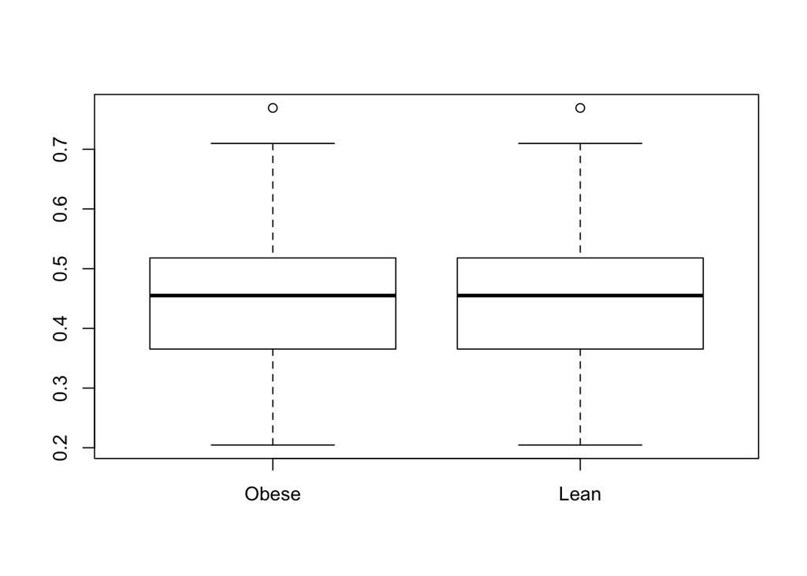

```r
####Beta diversity and microbiome divergence####

data(dietswap)
pseq<-dietswap
##Lets look at the new data set we will be using
View(otu_table(pseq))
View(tax_table(pseq))
View(sample_data(pseq))
##Calculate group divergences within the bmi groups
##This measure is sensitive to sample size
##If using NGS data it is recommended to subsample or bootstrap to avoid
##bias. This sample data is from a microarray so we don't have to
##worry about uneven sample sizes
b.obese<-divergence(subset_samples(pseq,bmi_group="obese"),method="bray")
b.lean<-divergence(subset_samples(pseq,bmi_group="lean"),method="bray")
boxplot(list(Obese=b.obese,Lean=b.lean))
```

```r
##The amount of diversity between samples in each group appears equal
```

# alpha diversity in dietswap

```r
##Lets Check the alpha diversity on this set
##Only retain taxa that are present and calculate diversity indices
ps1<-prune_taxa(taxa_sums(pseq)>0,pseq)
tab<-diversity(ps1,index="all") #update diversity function
View(tab)
##Get the sample meta data
ps1.meta<-meta(ps1)
kable(head(ps1.meta))
```

|  | subject | sex | nationality | group | sample | timepoint | timepoint.within.group | bmi_group |
| --- | --- | --- | --- | --- | --- | --- | --- | --- |
| Sample-1 | byn | male | AAM | DI | Sample-1 | 4 | 1 | obese |
| Sample-2 | nms | male | AFR | HE | Sample-2 | 2 | 1 | lean |
| Sample-3 | olt | male | AFR | HE | Sample-3 | 2 | 1 | overweight |
| Sample-4 | pku | female | AFR | HE | Sample-4 | 2 | 1 | obese |
| Sample-5 | qjy | female | AFR | HE | Sample-5 | 2 | 1 | overweight |
| Sample-6 | riv | female | AFR | HE | Sample-6 | 2 | 1 | obese |

```r
##Add the diversity table to the metadata
ps1.meta$Shannon<-tab$shannon
ps1.meta$InverseSimpson<-tab$inverse_simpson
##We have created a table that we can use for plotting data
View(ps1.meta)
```

# Shannon Diversity across groups

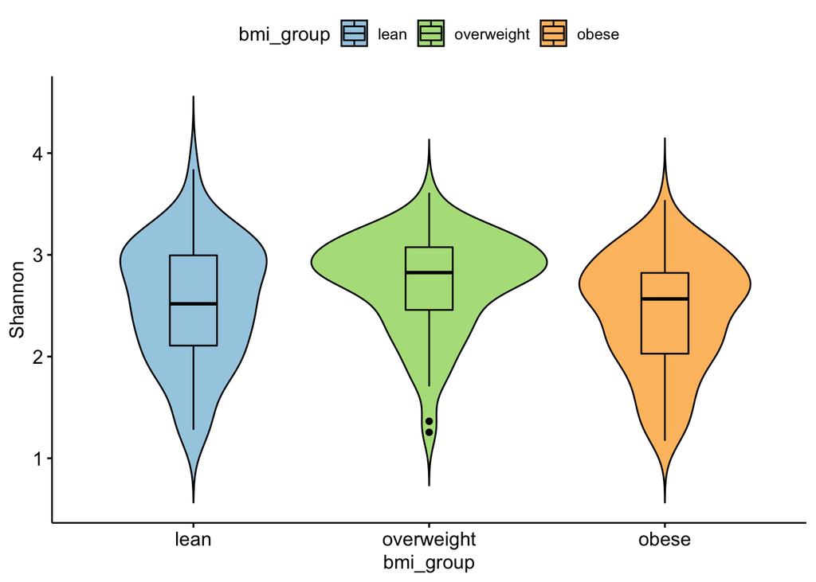

```r
##Compare the differences in Shannon index between BMI groups
##Create a list of pairwise comparisions
bmi<-levels(ps1.meta$bmi_group) #get the variables
bmi.pairs<-combn(bmi,2,simplify = F)
##Create a violin plot
p1<-ggviolin(ps1.meta,x="bmi_group",y="Shannon",add="boxplot",fill="bmi_group",
             palette = c("#a6cee3", "#b2df8a", "#fdbf6f"))
print(p1)
```

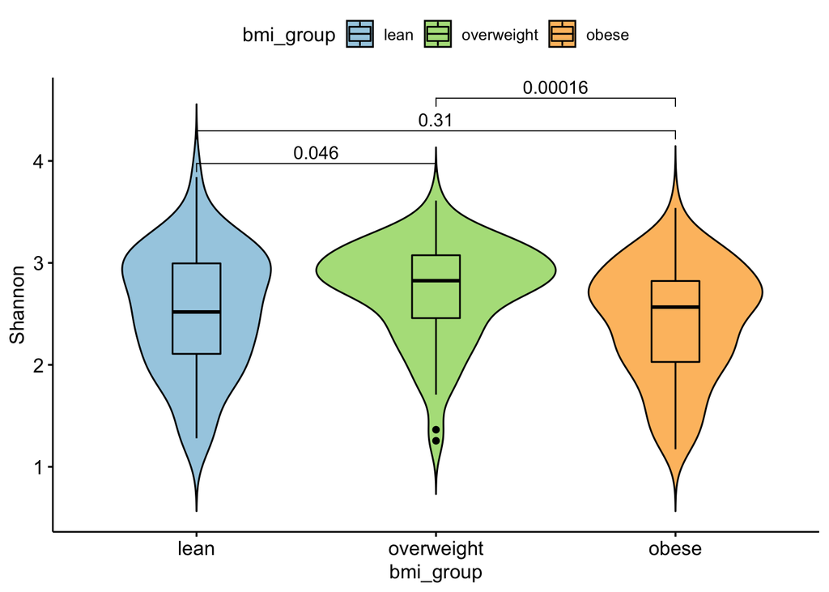

```r
##Add stats (Wilcoxon test)--From the documentation. I think the warnings are because there are not enough replicates
p1<-p1+stat_compare_means(comparisons = bmi.pairs,method="wilcox.test")
print(p1)
```

```r
##Diversity seems to be a little higher in the overweight group an not
##significantly different between the lean and obese groups
##This is different from what is usually reported.
## Can anyone think of an explanation?
```

# beta diversity over time helper functions

Write some functions here to calculate beta diversity directly, also dropping the “ED” group because it has some problems.

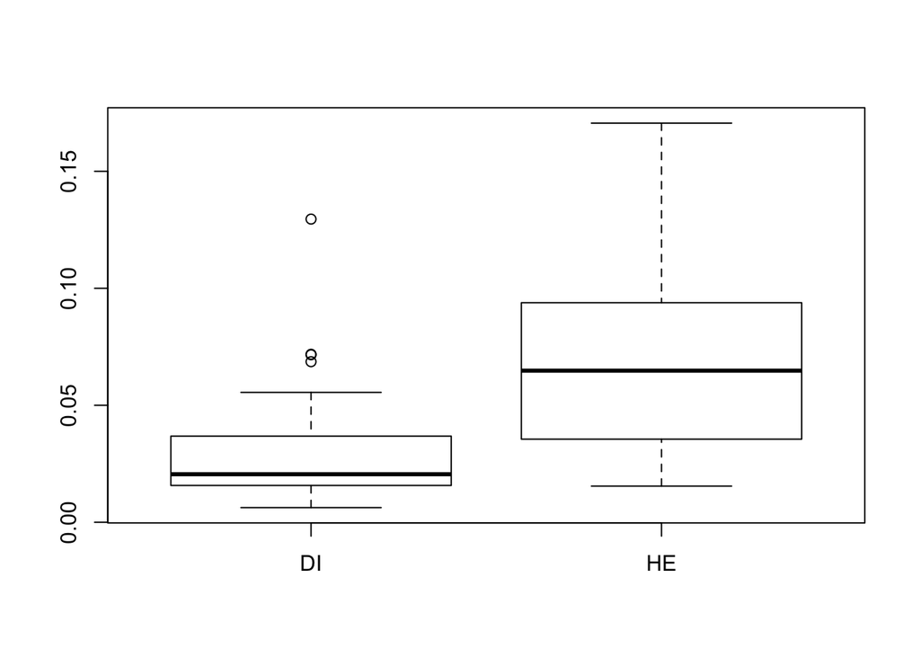

```r
##Let's now quantify how a persons microbiome changes over time
##Quantify beta diversity within subjects over time
subject_beta_diversity_over_time<-function(phyloseq_obj){
  betas<-list()
  df_meta<-meta(phyloseq_obj)
  ##We're dropping the ED group because the way it is encoded
  ##makes it difficult to interpret
  df_meta<-df_meta[which(df_meta$group != "ED"),]
  View(df_meta)
  groups<-as.character(unique(df_meta$group))
  for(g in groups){
    df<-subset(meta(pseq),group==g)
    beta<-c()

    for(subj in df$subject){
      dfs<-subset(df,subject==subj)
      #Check that subject has 2 time points
      if(nrow(dfs)==2){
        s<-as.character(dfs$sample)
        #Calculate the beta diversity directly
        beta[[subj]]<-1-cor(abundances(phyloseq_obj)[,s[[1]]],
                            abundances(phyloseq_obj)[,s[[2]]],
                            method="spearman")
      }
    }
    betas[[g]]<-beta
  }
  return(betas)
}


betas<-subject_beta_diversity_over_time(pseq)
##DI is during diet intervention HE is baseline
##The end of dietary intervention
##Subjects microbiomes became more similar when they were eating
##the experimental diets
boxplot(betas)
```

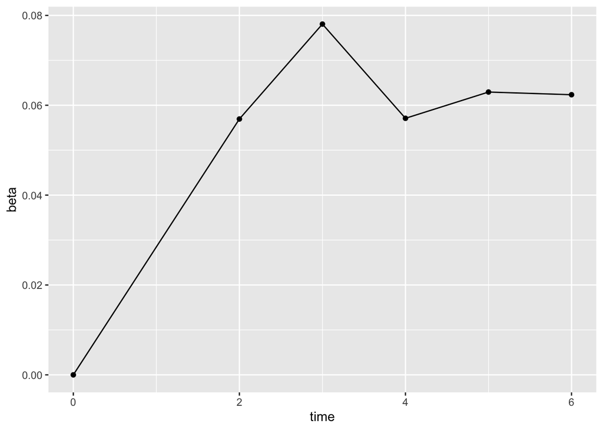

```r
##Calculate change in beta diversity (community dismilarity) over time within a single individual
##Identify the subject with the longest time series (most time points)
s<-names(which.max(sapply(split(meta(pseq)$timepoint,meta(pseq)$subject),function (x){length(unique(x))})))
##Pick the metadata for this subject and sort the samples by time
library(dplyr)
df<-meta(pseq) %>% filter(subject==s) %>% arrange(timepoint)

calculate_individual_beta_diversity_over_time<-function(df,pseq){
  ##Calculate how the sample diversity changes relative to baseline
  beta<-c(0,0) #Baseline similarity
  #s0<-subset(df,time=0)$sample
  s0<-df[which(df$timepoint==1),]$sample
  #print(s0)
  for(tp in df$timepoint[-1]){
    #Pick the samples for this subject
    #If the same time point has more than one sample, pick one at random
    st<-sample(subset(df,timepoint==tp)$sample,1)

    a<-abundances(pseq)
    #print(a[,s0])
    b<-1-cor(a[,s0],a[,st],method="spearman")
    beta<-rbind(beta,c(tp,b))
  }
  colnames(beta)<-c("time","beta")
  beta<-as.data.frame(beta)
  return(beta)
}

df_beta<-calculate_individual_beta_diversity_over_time(df,pseq)

library(ggplot2)
p<-ggplot(df_beta,aes(x=time,y=beta))+geom_point()+geom_line()
print(p)
```

# Microbiome Composition

What are the phylum composing the core microbiome?

[figure not shown]

```r
####Microbiome Composition plots####

##Compute relative level of each taxa
pseq.rel<-microbiome::transform(pseq,"compositional")
##Return a phyloseq object of the core microbiota

pseq.core<-core(pseq.rel,detection = 0,prevalence = 0.5)

pseq.core<-subset_samples(pseq.core,group="HE" & timepoint.within.group==1)
pseq.core.phylum<-aggregate_taxa(pseq.core,level="Phylum")


theme_set(theme_bw(21))

##Remember to save as 10x10
p <- plot_composition(pseq.core.phylum,group_by="nationality") +
  guides(fill = guide_legend(ncol = 1)) +
  labs(x = "Samples", y = "Relative abundance",
       title = "Relative abundance data",
       subtitle = "Subtitle",
       caption = "Caption text.")+
  scale_fill_manual(values = default_colors("Phylum"))


print(p)
```

# More detailed analysis & plotting of the core microbiome

Core microbiome is calculated with a combination of detection (otu percentage), and prevalence (sample percentence) cutoffs).

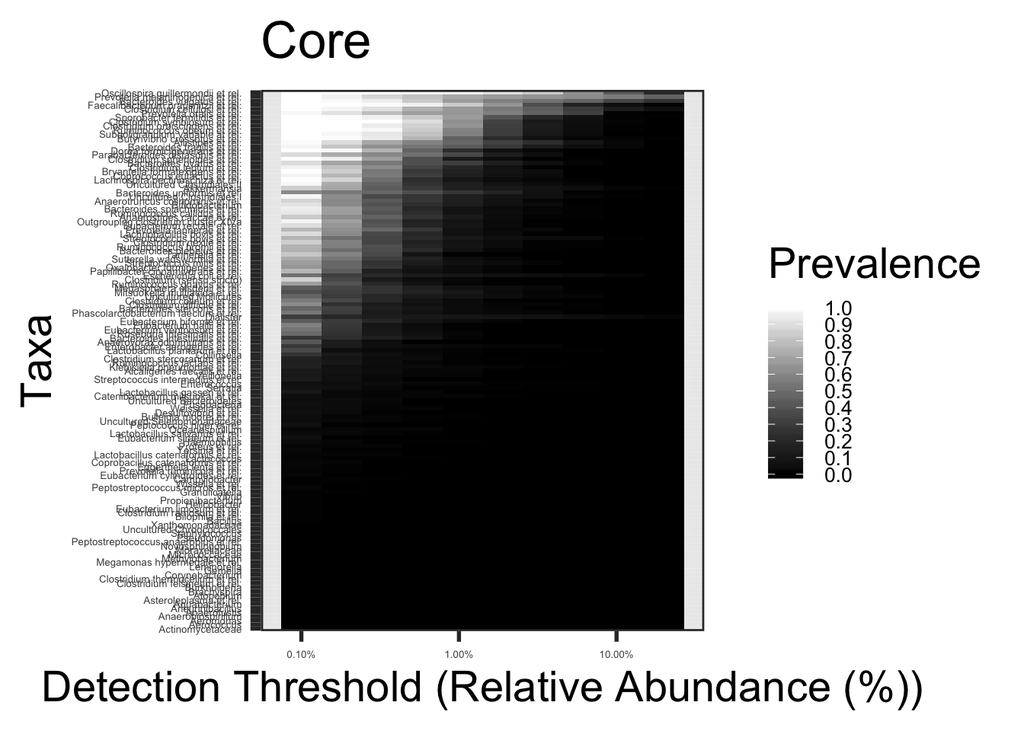

```r
 ####Core microbiome####
##Return the names of the taxa that excede given prevelence and detection thresholds
core.taxa.standard<-core_members(pseq.rel,detection=0,prevalence = 50/100)
##Return a phyloseq object of the core microbiota
pseq.core<-core(pseq.rel,detection = 0,prevalence = 0.5)
##Get taxa names
core.taxa<-taxa(pseq.core)
##Sum of abundances of the core members in each sample (Fraction of each sample composed of the
##core groups)
core.abundance<-sample_sums(core(pseq.rel,detection = 0.01,prevalence = 0.95))
##Core heatmaps
##Core with compositionals
prevalences <- seq(.05, 1, .05)
detections <- 10^seq(log10(1e-3), log10(.2), length = 10)

# Also define gray color palette
gray <- gray(seq(0,1,length=5))
p <- plot_core(pseq.rel, plot.type = "heatmap", colours = gray,
               prevalences = prevalences, detections = detections) +
  xlab("Detection Threshold (Relative Abundance (%))")+
  theme(axis.text=element_text(size=5),legend.text=element_text(size=10))
print(p)
```

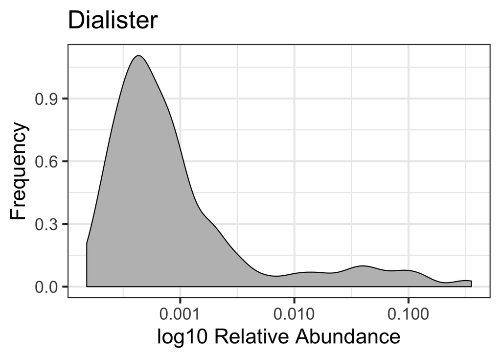

```r
##Check abundance of specific taxon
plot_density(pseq.rel,variable = "Dialister",log10=TRUE)+xlab("log10 Relative Abundance")
```

# ordination - representing data in 2d space, usually followed by some clustering

Ordination is a general ecological framework to recast the high-dimensional OTU data in a 2d plane, usually followed by some clustering. If things go well, samples will cluster relative to some sample/treatment data (eg bmi, or as seen below, nationality)

There are a variety of ordination methods and distances, and all will affect the grouping slightly

For a more extensive example on the differences between examples, [see](https://joey711.github.io/phyloseq/plot_ordination-examples.html), which is the underlying function called by plot_landscape().

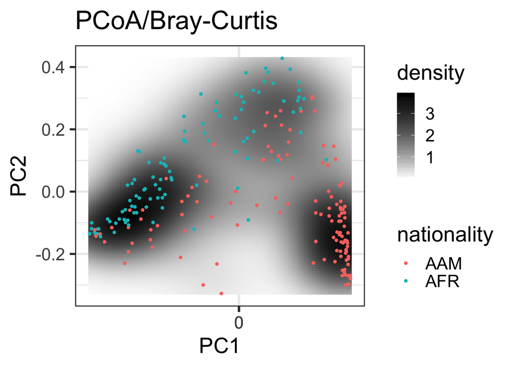

```r
####Ordination plotting####
p<-plot_landscape(pseq.core,method="PCoA",distance="bray",col="nationality")+
  labs(title="PCoA/Bray-Curtis")
print(p)
```

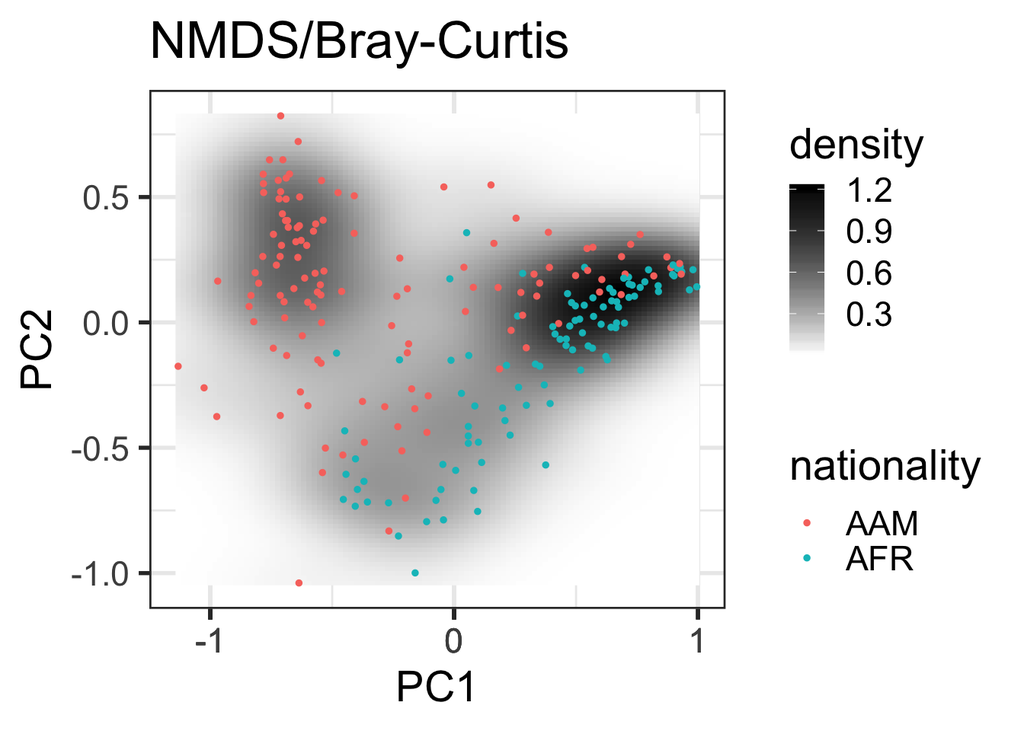

```r
####Ordination plotting####
set.seed(423542)
p<-plot_landscape(pseq.core,method="NMDS",distance="bray",col="nationality")+
  labs(title="NMDS/Bray-Curtis")
print(p)
```

```r
library(DESeq2)
##Make AFR (African) the reference group
sample_data(pseq)$nationality<-relevel(sample_data(pseq)$nationality, "AFR")

##Subset the data so that you only have the first baseline measurements
pseq.subset<-subset_samples(pseq,group=="HE" & timepoint.within.group==1)
##Convert data into a format that can be used by DESeq
##Group samples by nationality
pseq.deseq<-phyloseq_to_deseq2(pseq.subset, ~nationality)
##Perform normalization and differential abundance tests
pseq.deseq<-DESeq(pseq.deseq,test="Wald",fitType="parametric")
```

```
## -- replacing outliers and refitting for 13 genes
## -- DESeq argument 'minReplicatesForReplace' = 7
## -- original counts are preserved in counts(dds)
```

```r
##Get and filter the results
res<-results(pseq.deseq,cooksCutoff = FALSE)
alpha<-0.01
res.sig<-res[which(res$padj<=alpha),]
res.sig <-cbind(as(res.sig, "data.frame"), as(tax_table(pseq)[rownames(res.sig), ], "matrix"))
##Write results to file
write.csv(res.sig,file=here::here("Routput/differential_taxa_abundance.csv"))
```